# 16 years of FDIC Deposit Data

Edgar Ruiz

March 4, 2016

## Background

Banks and other financial institutions submit to the FDIC a report of all of the money held for deposit at each of their branches. A compilation of the reports from each bank is available as a single dataset in the FDIC’s website.

This report will detail the steps taken to analyze the FDIC ‘Summary of Deposit’ for each dataset between 2000 and 2015.

## The analysis

Loading the needed libraries to run the code

```r
library(scales)
library(data.table)
library(stringr)
library(plyr)
library(ggplot2)
library(maps)
library(ggthemes)
library(ggExtra)
library(forecast)
```

### Initial data load

```r
get.files <- list.files()
sod.location <- str_detect(get.files, "ALL_")
sod.files <- get.files[sod.location]

all.sod <- NULL
for(j in 1:length(sod.files)){all.sod  <- rbind(as.data.frame(fread(sod.files[j])),all.sod)}

#---------- The totals of deposits per branch field had commas and was in Thousands----------------
all.sod$DEPSUMBR <- str_replace_all(all.sod$DEPSUMBR, ",","")
all.sod$DEPSUMBR <- sapply(all.sod$DEPSUMBR, as.numeric)
all.sod$DEPSUMBR <- all.sod$DEPSUMBR * 1000
# --Combined institutions that belong to the same holding company into the 'institution' field-----
all.sod$institution <- all.sod$NAMEHCR
all.sod$institution[is.null(all.sod$institution)] <- all.sod$NAMEFULL[is.null(all.sod$institution)]
all.sod$institution[all.sod$institution==""] <- all.sod$NAMEFULL[all.sod$institution==""]
all.sod$institution <- sapply(all.sod$institution, str_to_upper)
current.sod <- all.sod[all.sod$ADDRESS!=all.sod$ADDRESBR,]
#------------------------- Annual deposit totals by State -----------------------------------------
sod.by.state <-aggregate(DEPSUMBR~YEAR+STALPBR, data=current.sod, FUN="sum")
sod.by.state$DEPSUMBR <- sod.by.state$DEPSUMBR  / 100000
#----------------------------------- Annual bank count --------------------------------------------
sod.by.year.banks <- count(all.sod, c("YEAR", "institution"))
sod.by.year.banks <-  sod.by.year.banks[,c(1,2)]
sod.by.year.banks <-  count(sod.by.year.banks , c("YEAR"))

#----------------------------------- Annual branch count -----------------------------------------
sod.by.year.branches <- count(all.sod, c("YEAR"))
#---------------------- Annual deposit totals -----------------------------------------------------
sod.by.year.deposits <- aggregate(DEPSUMBR~YEAR, data=all.sod, FUN="sum")
sod.by.year.deposits$y <-  sod.by.year.deposits$DEPSUMBR / 10000000000
#---------------------- State conversion file -----------------------------------------------------
states <- read.csv("states.csv", header = TRUE)
```

## Infographic

### Loading predictive models

The following code prepares 3 ARIMA forcasting models which attempt to predict the levels of deposits, banking institutions and branches for the next 5 years. The model selection for each is detailed in a different R Markup document.

Preparing model for deposit levels

```r
deposits.ts <- ts(sod.by.year.deposits$y)
deposits.diff <- (diff(deposits.ts))*1.2
deposits.diff.total <- diff(ts(sod.by.year.deposits$DEPSUMBR))
a2 <- arima(deposits.ts, order=c(1,1,1))
a2.pred <- predict(a2, n.ahead = 5)
u <- a2.pred$pred + (1.96*a2.pred$se)
l <- a2.pred$pred - (1.96*a2.pred$se)
years <- c(2016:2020)
deposits.predict <- as.data.frame(cbind(years,l , a2.pred$pred, u))
colnames(deposits.predict) <- c("year","lower","fit","upper")
c2015 <- sod.by.year.deposits[sod.by.year.deposits=="2015",c(1,3,3,3)]
colnames(c2015) <- c("year","lower","fit","upper")
deposits.predict <- rbind(deposits.predict, c2015)
```

Preparing model for banking institution levels

```r
sod.by.year.banks$y <- sod.by.year.banks$freq/8
banks.ts <- ts(sod.by.year.banks$freq)

a2 <- arima(banks.ts, order=c(2,2,1))



a2.pred <- predict(a2, n.ahead = 5)
u <- a2.pred$pred + (1.96*a2.pred$se)
l <- a2.pred$pred - (1.96*a2.pred$se)
years <- c(2016:2020)
banks.predict <- as.data.frame(cbind(years,l , a2.pred$pred, u))
colnames(banks.predict) <- c("year","label.lower","label.fit","label.upper")

banks.predict$lower <- banks.predict$label.lower/8
banks.predict$fit <- banks.predict$label.fit/8
banks.predict$upper <- banks.predict$label.upper/8

c2015 <- sod.by.year.banks[sod.by.year.banks=="2015",c(1,2,2,2,3,3,3)]
colnames(c2015) <- c("year","label.lower","label.fit","label.upper", "lower","fit","upper")
banks.predict <- rbind(banks.predict, c2015)
```

Preparing model for branch levels

```r
sod.by.year.branches$y <- sod.by.year.branches$freq/80

branches.ts <- ts(sod.by.year.branches$freq)
a2 <- arima(branches.ts, order=c(2,2,1))



a2.pred <- predict(a2, n.ahead = 5)
u <- a2.pred$pred + (1.96*a2.pred$se)
l <- a2.pred$pred - (1.96*a2.pred$se)
years <- c(2016:2020)
branches.predict <- as.data.frame(cbind(years,l , a2.pred$pred, u))
colnames(branches.predict) <- c("year","label.lower","label.fit","label.upper")

branches.predict$lower <- branches.predict$label.lower/80
branches.predict$fit <- branches.predict$label.fit/80
branches.predict$upper <- branches.predict$label.upper/80

c2015 <- sod.by.year.branches[sod.by.year.branches=="2015",c(1,2,2,2,3,3,3)]

colnames(c2015) <- c("year","label.lower","label.fit","label.upper", "lower","fit","upper")
branches.predict <- rbind(branches.predict, c2015)
```

### Loading Functions

```r
#------------------------------------- Axis Labels ------------------------------------------------
abbrev_number <-  function(x){
  new_vector <- NULL
  for(j in 1 : length(x)){
    if(is.na(x[j])){0 ; x[j]<-0}
    if(x[j]>=1000){new_number <- paste(round(x[j] / 1000,1),"K", sep="")}
    if(x[j]>=1000000){new_number <- paste(round(x[j] / 1000000,1),"M", sep="")}
    if(x[j]>=1000000000){new_number <- paste(round(x[j] / 1000000000000,1),"T", sep="")}
    if(x[j]>=1000000000000){new_number <- paste(round(x[j] / 1000000000000,1),"T", sep="")}
    new_vector <- c(new_vector,new_number)
  }
return(new_vector)}

#------------------------------------Year scale 'x' axis location ---------------------------------
year.x <- function(year){
  timeline.length <- 3200
  timeline.left <- 180
  timeline.start <- 2000
  timeline.end <- 2020
  year.mid <- timeline.length / (timeline.end-timeline.start)
  year.location <- year - timeline.start
  return((year.mid*year.location)+timeline.left)  }
```

### Creating the graph

Setting up the colors and plot options

```r
color.background <- "brown"
color.theme1 <- "white"
color.theme2 <- "orange"
color.theme3 <- "yellow"
color.theme4 <- "black"

timeline.top <- 1200
y.adjustment <- timeline.top-325

year.data <- c("00", "05","10","15", "20")
year.locations <- c(year.x(2000),year.x(2005),year.x(2010),year.x(2015),year.x(2020))

ig <- ggplot() + theme_pander() + removeGrid()
ig <- ig + theme(axis.title = element_blank())
ig <- ig + theme(axis.text.x = element_blank())
ig <- ig + theme(axis.text.y = element_blank())
ig <- ig + theme(axis.ticks = element_blank())
ig <- ig + theme(axis.line = element_blank())
ig <- ig + theme(legend.position ="none")
ig <- ig + theme(panel.background = element_rect(fill = color.background))
```

Graph main title and captions

```r
ig <- ig + geom_text(aes(x=1, y=2400, label="FDIC Deposit Data and Forecast", hjust=0), size=8, color=color.theme1)
ig <- ig + geom_text(aes(x=1, y=2300, label="2000-2020", hjust=0), size=6, color=color.theme1)
ig <- ig + geom_text(aes(x=3700, y=-800, label="Edgar Ruiz - March, 2016", hjust=1), size=4, color=color.theme1)
ig <- ig + geom_text(aes(x=3700, y=-850, label="Source: FDIC.gov", hjust=1), size=4, color=color.theme1)
```

### Deposit, Bank and Branch area graphs

Deposit amount levels and predictions

```r
ig <- ig + geom_area(aes(x=year.x(sod.by.year.deposits$YEAR), y=sod.by.year.deposits$y+y.adjustment), fill=color.theme2)
ig <- ig + geom_area(aes(x=year.x(deposits.predict$year), y=deposits.predict$upper+y.adjustment), fill=color.theme2)
ig <- ig + geom_area(aes(x=year.x(deposits.predict$year), y=deposits.predict$fit+y.adjustment), fill=color.theme3)
ig <- ig + geom_area(aes(x=year.x(deposits.predict$year), y=deposits.predict$lower+y.adjustment), fill=color.background)
ig <- ig + geom_text(aes(x=year.x(sod.by.year.deposits$YEAR), y=sod.by.year.deposits$y+y.adjustment+50, label=paste("$",abbrev_number(sod.by.year.deposits$DEPSUMBR), sep="")), size=3, color=color.theme3)
ig <- ig + geom_rect(aes(xmin=year.x(2000),x=year.x(2000), xmax=year.x(2020), y=timeline.top,  ymin=timeline.top, ymax=0), fill=color.background)
ig <- ig + geom_rect(aes(xmin=year.x(2000),x=year.x(2000), xmax=year.x(2015), y=timeline.top,  ymin=timeline.top, ymax=0), fill=color.theme3)
predict.labels <- deposits.predict[deposits.predict$year==2016 | deposits.predict$year==2018 | deposits.predict$year==2020,]
ig <- ig + geom_text(aes(x=year.x(predict.labels$year), y=predict.labels$upper+y.adjustment+50, label=paste("$" , abbrev_number(predict.labels$upper*10000000000), sep="")), size=3, color=color.theme3)
ig <- ig + geom_text(aes(x=year.x(predict.labels$year), y=predict.labels$lower+y.adjustment-50, label = paste("$", abbrev_number(predict.labels$lower*10000000000),sep="")), size=3, color=color.theme3)
ig <- ig + geom_text(aes(x=year.x(2010), y=y.adjustment+600, label="FDIC Deposits"), size=5.5, color=color.theme3)
ig <- ig + geom_text(aes(x=year.x(2010)+0.7, y=y.adjustment+600+0.7, label="FDIC Deposits"), size=5.5, color=color.background)
```

Bank institutions levels and predictions

```r
ig <- ig + geom_area(aes(x=year.x(sod.by.year.banks$YEAR), y=sod.by.year.banks$y + y.adjustment - 720),fill=color.background)
ig <- ig + geom_area(aes(x=year.x(banks.predict$year), y=banks.predict$upper + y.adjustment - 720), fill=color.theme2)
ig <- ig + geom_area(aes(x=year.x(banks.predict$year), y=banks.predict$fit + y.adjustment - 720), fill=color.theme3)
ig <- ig + geom_area(aes(x=year.x(banks.predict$year), y=banks.predict$lower + y.adjustment - 720), fill=color.background)
ig <- ig + geom_text(aes(x=year.x(sod.by.year.banks$YEAR), y=sod.by.year.banks$y + y.adjustment - 770, label=abbrev_number(sod.by.year.banks$freq)), size=3, color=color.theme3)
bank.labels <- banks.predict[banks.predict$year==2016 | banks.predict$year==2018 | banks.predict$year==2020,]
ig <- ig + geom_text(aes(x=year.x(bank.labels$year), y=bank.labels$upper+y.adjustment-680, label=abbrev_number(bank.labels$label.upper)), size=3, color=color.theme3)
ig <- ig + geom_text(aes(x=year.x(bank.labels$year), y=bank.labels$lower+y.adjustment-770, label=abbrev_number(bank.labels$label.lower)), size=3, color=color.theme3)
ig <- ig + geom_text(aes(x=year.x(2010), y=y.adjustment+240, label="Number of Banks"), size=5, color=color.theme1)
ig <- ig + geom_text(aes(x=year.x(2010)+0.7, y=y.adjustment+240+0.7, label="Number of Banks"), size=5, color=color.background)
```

Branch levels and predictions

```r
branch.offset <- 700
branch.seq <- seq(1, nrow(sod.by.year.branches), 2)
ig <- ig + geom_area(aes(x=year.x(sod.by.year.branches$YEAR), y=sod.by.year.branches$y-branch.offset),fill=color.theme2)
ig <- ig + geom_rect(aes(xmin=year.x(2000),x=year.x(2000), xmax=year.x(2015), y=0 , ymin=min(sod.by.year.branches$y)-branch.offset-250, ymax=0), fill=color.background)
ig <- ig + geom_area(aes(x=year.x(branches.predict$year), y=branches.predict$fit-branch.offset), fill=color.theme3)
ig <- ig + geom_area(aes(x=year.x(branches.predict$year), y=branches.predict$lower-branch.offset), fill=color.background)

ig <- ig + geom_text(aes(x=year.x(sod.by.year.branches$YEAR[branch.seq]), y=sod.by.year.branches$y[branch.seq]-branch.offset+30, label=abbrev_number(sod.by.year.branches$freq[branch.seq])), size=3, color=color.theme3)

ig <- ig + geom_text(aes(x=year.x(sod.by.year.branches$YEAR[branch.seq+1]), y=sod.by.year.branches$y[branch.seq+1]-branch.offset+70, label=abbrev_number(sod.by.year.branches$freq[branch.seq+1])), size=3, color=color.theme3)

ig <- ig + geom_segment(aes(x=year.x(sod.by.year.branches$YEAR[branch.seq+1]),xend=year.x(sod.by.year.branches$YEAR[branch.seq+1]), y=sod.by.year.branches$y[branch.seq+1]-branch.offset+50, yend=sod.by.year.branches$y[branch.seq+1]-branch.offset), size=1, color=color.theme3)
branch.labels <- branches.predict[branches.predict$year==2016 | branches.predict$year==2018 | branches.predict$year==2020,]
ig <- ig + geom_text(aes(x=year.x(branch.labels$year), y=branch.labels$fit-branch.offset+50, label=abbrev_number(branch.labels$label.fit)), size=3, color=color.theme3)
ig <- ig + geom_text(aes(x=year.x(branch.labels$year), y=branch.labels$lower-branch.offset-50, label=abbrev_number(branch.labels$label.lower)), size=3, color=color.theme3)
ig <- ig + geom_text(aes(x=year.x(2008), y=branch.offset-400, label="Number of Branches"), size=5.5, color=color.theme2)
ig <- ig + geom_text(aes(x=year.x(2008)+0.7, y=branch.offset-400+0.7, label="Number of Branches"), size=5.5, color=color.background)
```

Year-over-year change bar graphs

```r
change.years <- c(2001:2015)
change.adjustment <- 50
change.width <- 7.5
change.color <- color.theme3
ig <- ig + geom_segment(aes(x=year.x(change.years[1]),xend=year.x(change.years[1]), y=timeline.top+deposits.diff[change.years[1]-2000]+change.adjustment,  yend=timeline.top+change.adjustment), size=change.width, color=change.color)
ig <- ig + geom_segment(aes(x=year.x(change.years[2]),xend=year.x(change.years[2]), y=timeline.top+deposits.diff[change.years[2]-2000]+change.adjustment,  yend=timeline.top+change.adjustment), size=change.width, color=change.color)
ig <- ig + geom_segment(aes(x=year.x(change.years[3]),xend=year.x(change.years[3]), y=timeline.top+deposits.diff[change.years[3]-2000]+change.adjustment,  yend=timeline.top+change.adjustment), size=change.width, color=change.color)
ig <- ig + geom_segment(aes(x=year.x(change.years[4]),xend=year.x(change.years[4]), y=timeline.top+deposits.diff[change.years[4]-2000]+change.adjustment,  yend=timeline.top+change.adjustment), size=change.width, color=change.color)
ig <- ig + geom_segment(aes(x=year.x(change.years[5]),xend=year.x(change.years[5]), y=timeline.top+deposits.diff[change.years[5]-2000]+change.adjustment,  yend=timeline.top+change.adjustment), size=change.width, color=change.color)
ig <- ig + geom_segment(aes(x=year.x(change.years[6]),xend=year.x(change.years[6]), y=timeline.top+deposits.diff[change.years[6]-2000]+change.adjustment,  yend=timeline.top+change.adjustment), size=change.width, color=change.color)
ig <- ig + geom_segment(aes(x=year.x(change.years[7]),xend=year.x(change.years[7]), y=timeline.top+deposits.diff[change.years[7]-2000]+change.adjustment,  yend=timeline.top+change.adjustment), size=change.width, color=change.color)
ig <- ig + geom_segment(aes(x=year.x(change.years[8]),xend=year.x(change.years[8]), y=timeline.top+deposits.diff[change.years[8]-2000]+change.adjustment,  yend=timeline.top+change.adjustment), size=change.width, color=change.color)
ig <- ig + geom_segment(aes(x=year.x(change.years[9]),xend=year.x(change.years[9]), y=timeline.top+deposits.diff[change.years[9]-2000]+change.adjustment,  yend=timeline.top+change.adjustment), size=change.width, color=change.color)
ig <- ig + geom_segment(aes(x=year.x(change.years[10]),xend=year.x(change.years[10]), y=timeline.top+deposits.diff[change.years[10]-2000]+change.adjustment,  yend=timeline.top+change.adjustment), size=change.width, color=change.color)
ig <- ig + geom_segment(aes(x=year.x(change.years[11]),xend=year.x(change.years[11]), y=timeline.top+deposits.diff[change.years[11]-2000]+change.adjustment,  yend=timeline.top+change.adjustment), size=change.width, color=change.color)
ig <- ig + geom_segment(aes(x=year.x(change.years[12]),xend=year.x(change.years[12]), y=timeline.top+deposits.diff[change.years[12]-2000]+change.adjustment,  yend=timeline.top+change.adjustment), size=change.width, color=change.color)
ig <- ig + geom_segment(aes(x=year.x(change.years[13]),xend=year.x(change.years[13]), y=timeline.top+deposits.diff[change.years[13]-2000]+change.adjustment,  yend=timeline.top+change.adjustment), size=change.width, color=change.color)
ig <- ig + geom_segment(aes(x=year.x(change.years[14]),xend=year.x(change.years[14]), y=timeline.top+deposits.diff[change.years[14]-2000]+change.adjustment,  yend=timeline.top+change.adjustment), size=change.width, color=change.color)
ig <- ig + geom_segment(aes(x=year.x(change.years[15]),xend=year.x(change.years[15]), y=timeline.top+deposits.diff[change.years[15]-2000]+change.adjustment,  yend=timeline.top+change.adjustment), size=change.width, color=change.color)
```

Timeline labels

```r
# Year timeline labels
ig <- ig + geom_segment(aes(x=year.x(2000),y=timeline.top, xend=year.x(2020), yend=timeline.top), size=3, color=color.theme1)
ig <- ig + geom_point(aes(x=year.locations, y=timeline.top), stat="identity", size = 10, color=color.theme1)
ig <- ig + geom_point(aes(x=year.locations, y=timeline.top), stat="identity", size = 8, color=color.background)
ig <- ig + geom_segment(aes(x=year.x(2000),y=timeline.top, xend=year.x(2020)-10, yend=timeline.top), size=1.5, color=color.background)
ig <- ig + geom_text(aes(x=year.locations, y=timeline.top, label=year.data), size=4, color=color.theme1)
ig <- ig + geom_text(aes(x=10, y=timeline.top, label="Year"), size=4, color=color.theme1)

# Year timeline labels
timeline.top2 <- timeline.top - 1080
ig <- ig + geom_segment(aes(x=year.x(2000),y=timeline.top2, xend=year.x(2020), yend=timeline.top2), size=3, color=color.theme1)
ig <- ig + geom_point(aes(x=year.locations, y=timeline.top2), stat="identity", size = 10, color=color.theme1)
ig <- ig + geom_point(aes(x=year.locations, y=timeline.top2), stat="identity", size = 8, color=color.background)
ig <- ig + geom_segment(aes(x=year.x(2000),y=timeline.top2, xend=year.x(2020)-10, yend=timeline.top2), size=1.5, color=color.background)
ig <- ig + geom_text(aes(x=year.locations, y=timeline.top2, label=year.data), size=4, color=color.theme1)
ig <- ig + geom_text(aes(x=10, y=timeline.top2, label="Year"), size=4, color=color.theme1)
```

### USA Maps

```r
#-------------------- Comparing and keeping 2000, 2005 and 2015 -----------------------------------
colnames(sod.by.state) <- c("year","state","deposits")
sod.by.state <- sod.by.state[sod.by.state$year==2000 | sod.by.state$year==2005 | sod.by.state$year==2010 | sod.by.state$year==2015 ,]
sod.by.state.previous <- sod.by.state
sod.by.state.previous$year <- sod.by.state.previous$year+5
sod.by.state.previous <- sod.by.state.previous[sod.by.state.previous$year<=2015,]
sod.by.state <- merge(x=sod.by.state, y=sod.by.state.previous, by=c("year","state"))
colnames(sod.by.state) <- c("year","state", "deposits","previous")
sod.by.state$difference <- sod.by.state$deposits - sod.by.state$previous
sod.by.state$change <- sod.by.state$difference / sod.by.state$previous
#------------------------- Removing US territories so as to keep the 50 states --------------------
sod.by.state <- sod.by.state[sod.by.state$state!="AS",]
sod.by.state <- sod.by.state[sod.by.state$state!="PW",]
sod.by.state <- sod.by.state[sod.by.state$state!="PR",]
sod.by.state <- sod.by.state[sod.by.state$state!="FM",]
sod.by.state <- sod.by.state[sod.by.state$state!="VI",]
sod.by.state <- sod.by.state[sod.by.state$state!="MH",]
sod.by.state <- sod.by.state[sod.by.state$state!="GU",]
sod.by.state <- sod.by.state[sod.by.state$state!="MA",]
sod.by.state <- sod.by.state[sod.by.state$state!="MP",]
```

Setting up the poligons for all 50 states and determining the ranking

```r
alaska_map <- map_data("world")
alaska_map <- alaska_map[is.na(alaska_map$subregion)==FALSE,]
alaska_map <- alaska_map[alaska_map$subregion=="Alaska",]
alaska_map$region <- "AK"
alaska_map <- alaska_map[alaska_map$long<0,]
alaska_map$long <- alaska_map$long * 8
alaska_map$lat <- alaska_map$lat * 5
alaska_map$long <- alaska_map$long   + 1900
alaska_map$lat <- alaska_map$lat - 800

hawaii_map <- map_data("world")
hawaii_map <- hawaii_map[is.na(hawaii_map$subregion)==FALSE,]
hawaii_map <- hawaii_map[hawaii_map$subregion=="Hawaii",]
hawaii_map$region <- "HI"
hawaii_map$long <- hawaii_map$long * 50
hawaii_map$lat <- hawaii_map$lat * 30
hawaii_map$long <- hawaii_map$long   + 8100
hawaii_map$lat <- hawaii_map$lat - 1100


states_map <- map_data("state")
states_map <- merge(x=states_map, y=states, by.x = "region", by.y="match1")
states_map$region <- states_map$abbrev
states_map$long <- states_map$long * 20
states_map$lat <- states_map$lat * 12
states_map$long <- states_map$long   + 2500
states_map$lat <- states_map$lat - 700
```

Creating map plots

```r
#------------------------------------------ 2005 --------------------------------------------------
state.2005 <-sod.by.state[sod.by.state$year==2005,]
state.2005$rank <- rank(state.2005$change, ties.method="first")

ig <- ig + geom_map(data=state.2005 , aes(map_id=state,fill = rank),map=states_map, color=color.theme1, size=0.1)+expand_limits(x = states_map$long, y = states_map$lat)
ig <- ig +geom_map(data=state.2005 , aes(map_id=state,fill = rank),map=alaska_map, color=color.theme1, size=0.1)+expand_limits(x = alaska_map$long, y = alaska_map$lat)
ig <- ig +geom_map(data=state.2005 , aes(map_id=state,fill = rank),map=hawaii_map, color=color.theme1, size=0.1)+expand_limits(x = hawaii_map$long, y = hawaii_map$lat)


#------------------------------------------ 2010 --------------------------------------------------
states_map$long <- states_map$long   + 1200
alaska_map$long <- alaska_map$long   + 1200
hawaii_map$long <- hawaii_map$long   + 1200
state.2010 <-sod.by.state[sod.by.state$year==2010,]
state.2010$rank <- rank(state.2010$change, ties.method="first")
ig <- ig +geom_map(data=state.2010 , aes(map_id=state,fill = rank),map=states_map, color=color.theme1, size=0.1)+expand_limits(x = states_map$long, y = states_map$lat)
ig <- ig +geom_map(data=state.2010 , aes(map_id=state,fill = rank),map=alaska_map, color=color.theme1, size=0.1)+expand_limits(x = alaska_map$long, y = alaska_map$lat)
ig <- ig +geom_map(data=state.2010 , aes(map_id=state,fill = rank),map=hawaii_map, color=color.theme1, size=0.2)+expand_limits(x = hawaii_map$long, y = hawaii_map$lat)
#------------------------------------------ 2015 --------------------------------------------------
states_map$long <- states_map$long   + 1200
alaska_map$long <- alaska_map$long   + 1200
hawaii_map$long <- hawaii_map$long   + 1200
state.2015 <-sod.by.state[sod.by.state$year==2015,]
state.2015$rank <- rank(state.2015$change, ties.method="first")
state.2015$zscore <- (state.2015$change - mean(state.2015$change))/ sd(state.2015$change)
ig <- ig +geom_map(data=state.2015 , aes(map_id=state,fill = rank),map=states_map, color=color.theme1, size=0.1)+expand_limits(x = states_map$long, y = states_map$lat)
ig <- ig +geom_map(data=state.2015 , aes(map_id=state,fill = rank),map=alaska_map, color=color.theme1, size=0.1)+expand_limits(x = alaska_map$long, y = alaska_map$lat)
ig <- ig +geom_map(data=state.2015 , aes(map_id=state,fill = rank),map=hawaii_map, color=color.theme1, size=0.1)+expand_limits(x = hawaii_map$long, y = hawaii_map$lat)
ig <- ig + scale_fill_gradient2( mid = color.theme2, low=color.background, high = color.theme3, midpoint = 25)
ig <- ig + geom_text(aes(x=c(500,1750,2900), y=-600, label= c("2000 - 2005","2005 - 2010","2010 - 2015")), size=4, color=color.theme1)

ig <- ig + geom_text(aes(x=1800, y=-10, label= "5-year % growth - Ranked by State"), size=6, color=color.theme1)
ig <- ig + geom_text(aes(x=year.x(change.years), y=timeline.top+change.adjustment+30, label=paste("", abbrev_number(deposits.diff.total),  sep="")), size=2.5, color=color.theme4)
ig <- ig + geom_text(aes(x=year.x(max(change.years))+500, y=timeline.top+change.adjustment+30, label="Year-over-year $ growth"), size=3.5, color=color.theme1)
ig <- ig + geom_segment(aes(x=year.x(max(change.years))+60, xend=year.x(max(change.years))+150,y=timeline.top+change.adjustment+30, yend=timeline.top+change.adjustment+30), size=1, color=color.theme1)
ig <- ig + geom_segment(aes(x=year.x(max(change.years))+62, xend=year.x(max(change.years))+100,y=timeline.top+change.adjustment+30, yend=timeline.top+change.adjustment+40), size=1, color=color.theme1)
ig <- ig + geom_segment(aes(x=year.x(max(change.years))+62, xend=year.x(max(change.years))+100,y=timeline.top+change.adjustment+30, yend=timeline.top+change.adjustment+20), size=1, color=color.theme1)

#----------------------------------------- Rank legends -------------------------------------------
legend.margin <- 1550
ig <- ig + geom_rect(aes( xmin=legend.margin, xmax=legend.margin+100, ymin=-700, ymax=-750), color=color.theme1, fill=color.theme3)
ig <- ig + geom_text(aes(x=legend.margin, y=-800, label="1st", hjust=0), size=3, color=color.theme1)
ig <- ig + geom_rect(aes( xmin=legend.margin+ 150, xmax=legend.margin+250, ymin=-700, ymax=-750), color=color.theme1, fill=color.theme2)
ig <- ig + geom_text(aes(x=legend.margin+145, y=-800, label="25th", hjust=0), size=3, color=color.theme1)
ig <- ig + geom_rect(aes( xmin=legend.margin +300, xmax=legend.margin+400, ymin=-700, ymax=-750), color=color.theme1, fill=color.background)
ig <- ig + geom_text(aes(x=legend.margin+295, y=-800, label="50th", hjust=0), size=3, color=color.theme1)
```

### Comments

```r
#----------------------------------------- Comment 1 ----------------------------------------------
point1.x <- 140; point1.y <- 1700
ig <- ig + geom_text(aes(x=point1.x,  y=point1.y+80, label="1", hjust=0 ),size=9, color=color.theme2)
ig <- ig + geom_rect(aes( xmin=point1.x+120, xmax=point1.x+1100, ymin=point1.y, ymax=point1.y+140), color=color.theme2, fill=color.theme2)
ig <- ig + geom_text(aes(x=point1.x+140,  y=point1.y+110, label="Before 2010, deposits", hjust=0 ),size=4, color=color.background)
ig <- ig + geom_text(aes(x=point1.x+140,  y=point1.y+70, label="grew consistently between ", hjust=0 ),size=4, color=color.background)
ig <- ig + geom_text(aes(x=point1.x+140,  y=point1.y+30, label="$300 and $500 Billion", hjust=0 ),size=4, color=color.background)
#----------------------------------------- Comment 2 ----------------------------------------------
point2.x <- 1750; point2.y <- 2150
ig <- ig + geom_text(aes(x=point2.x,  y=point2.y+80, label="2", hjust=0 ),size=9, color=color.theme2)
ig <- ig + geom_rect(aes( xmin=point2.x+120, xmax=point2.x+1100, ymin=point2.y, ymax=point2.y+140), color=color.theme2, fill=color.theme2)
ig <- ig + geom_text(aes(x=point2.x+140,  y=point2.y+110, label="Model is 95% certain that", hjust=0 ),size=4, color=color.background)
ig <- ig + geom_text(aes(x=point2.x+140,  y=point2.y+70, label="by 2020 deposits will reach", hjust=0 ),size=4, color=color.background)
ig <- ig + geom_text(aes(x=point2.x+140,  y=point2.y+30, label="$12.1T-to-$14.4T", hjust=0 ),size=4, color=color.background)
#----------------------------------------- Comment 3 ----------------------------------------------
point3.x <- 2650; point3.y <- 1400
ig <- ig + geom_text(aes(x=point3.x,  y=point3.y+80, label="3", hjust=0 ),size=9, color=color.theme2)
ig <- ig + geom_rect(aes( xmin=point3.x+120, xmax=point3.x+1050, ymin=point3.y, ymax=point3.y+140), color=color.theme2, fill=color.theme2)
ig <- ig + geom_text(aes(x=point3.x+140,  y=point3.y+110, label="Stalled growth in '10 was", hjust=0 ),size=4, color=color.background)
ig <- ig + geom_text(aes(x=point3.x+140,  y=point3.y+70, label="followed by a $600B jump,", hjust=0 ),size=4, color=color.background)
ig <- ig + geom_text(aes(x=point3.x+140,  y=point3.y+30, label="possible effects of QE2", hjust=0 ),size=4, color=color.background)
#----------------------------------------- Comment 4 ----------------------------------------------
point4.x <- 2650; point4.y <- 950
ig <- ig + geom_text(aes(x=point4.x,  y=point4.y+80, label="4", hjust=0 ),size=9, color=color.theme2)
ig <- ig + geom_rect(aes( xmin=point4.x+120, xmax=point4.x+1100, ymin=point4.y, ymax=point4.y+140), color=color.theme2, fill=color.theme2)
ig <- ig + geom_text(aes(x=point4.x+140,  y=point4.y+110, label="Model shows that in 2016,", hjust=0 ),size=4, color=color.background)
ig <- ig + geom_text(aes(x=point4.x+140,  y=point4.y+70, label="200-to-400 additional banks", hjust=0 ),size=4, color=color.background)
ig <- ig + geom_text(aes(x=point4.x+140,  y=point4.y+30, label="will come off the list", hjust=0 ),size=4, color=color.background)
#----------------------------------------- Comment 5 ----------------------------------------------
point5.x <- 140; point5.y <- 700
ig <- ig + geom_text(aes(x=point5.x,  y=point5.y+80, label="5", hjust=0 ),size=9, color=color.theme2)
ig <- ig + geom_rect(aes( xmin=point5.x+120, xmax=point5.x+1100, ymin=point5.y, ymax=point5.y+140), color=color.theme2, fill=color.theme2)
ig <- ig + geom_text(aes(x=point5.x+140,  y=point5.y+110, label="Branch levels declining.", hjust=0 ),size=4, color=color.background)
ig <- ig + geom_text(aes(x=point5.x+140,  y=point5.y+70, label="Model's lower range shows", hjust=0 ),size=4, color=color.background)
ig <- ig + geom_text(aes(x=point5.x+140,  y=point5.y+30, label="closures may accelerate ", hjust=0 ),size=4, color=color.background)
#----------------------------------------- Comment 6 ----------------------------------------------
point6.x <- 140; point6.y <- -850
ig <- ig + geom_text(aes(x=point6.x,  y=point6.y+80, label="6", hjust=0 ),size=9, color=color.theme2)
ig <- ig + geom_rect(aes( xmin=point6.x+120, xmax=point6.x+1200, ymin=point6.y, ymax=point6.y+140), color=color.theme2, fill=color.theme2)
ig <- ig + geom_text(aes(x=point6.x+140,  y=point6.y+110, label="Growth pattern changed", hjust=0 ),size=4, color=color.background)
ig <- ig + geom_text(aes(x=point6.x+140,  y=point6.y+70, label="during downturn, eastern", hjust=0 ),size=4, color=color.background)
ig <- ig + geom_text(aes(x=point6.x+140,  y=point6.y+30, label="states were the most affected.   ", hjust=0 ),size=4, color=color.background)
```

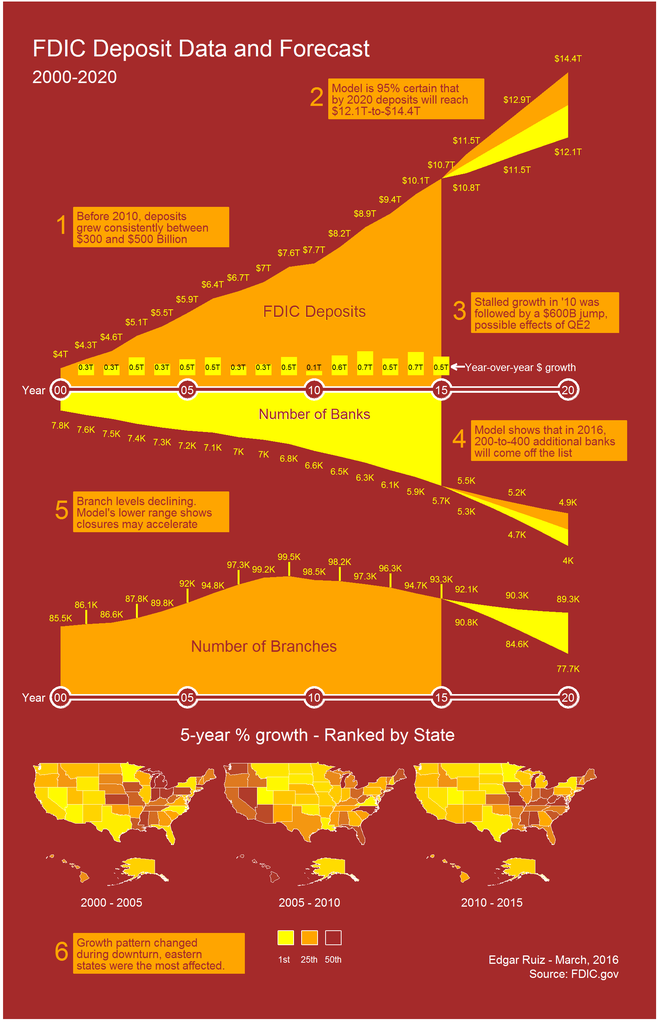

```r
ggsave("inforgraphic.png", width=8.5, height = 14, units=("in"))
print(ig)
```